# Data Wrangling for EDSDers

```r
nrow(ASFR1) # yup it's bigger now
```

```
## [1] 36400
```

Each subset now has single ages 15-49. We don’t know yet whether there were any pathological cases. Let’s make a scatterplot of MAB by TFR to find out.

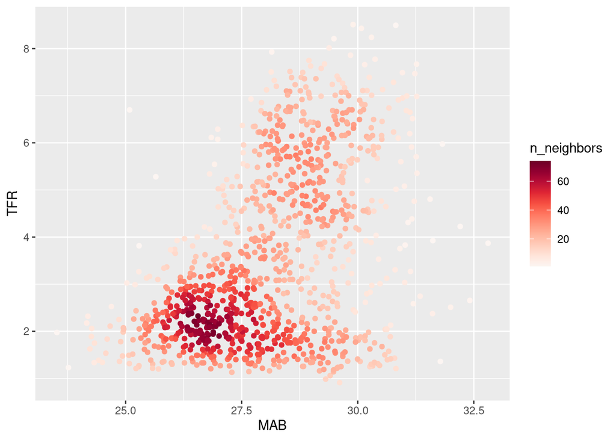

```r
#install.packages("ggpointdensity")
library(ggpointdensity)
library(colorspace)
ASFR1 <-
  ASFR1 %>%
  group_by(Country, ISO, Year) %>%
  mutate(MAB = sum(Age * asfr) / sum(asfr),
            TFR = sum(asfr),
            .groups = "drop")
ASFR1 %>%
  filter(Age == 30) %>%
  ggplot(mapping = aes(x = MAB, y = TFR)) +
  geom_pointdensity() +
  scale_color_continuous_sequential(palette = "Reds")
```

Now we start with the exercise. We bin TFRs into some intervals, let’s just say .25 or so. This can happen in a `mutate()` call, and we do it by subtracting the modulo using `%%` (super awesome operator). Next step is to group by `TFRint` and pick out the minumum and maximum MAB in each interval band.

```r
ASFRex <- ASFR1 %>%
  filter(MAB > 20) %>%
  mutate(TFRint = TFR - TFR %% .25) %>%
  group_by(TFRint) %>%
  mutate(extremes = case_when(
                      MAB == max(MAB) ~ "max",
                      MAB == min(MAB) ~ "min",
                      TRUE ~ as.character(NA)
  )) %>%
 filter(!is.na(extremes))
```

Now this is something we can plot! Let’s use the `ggridges` package to bring in the ridgeplot geom.

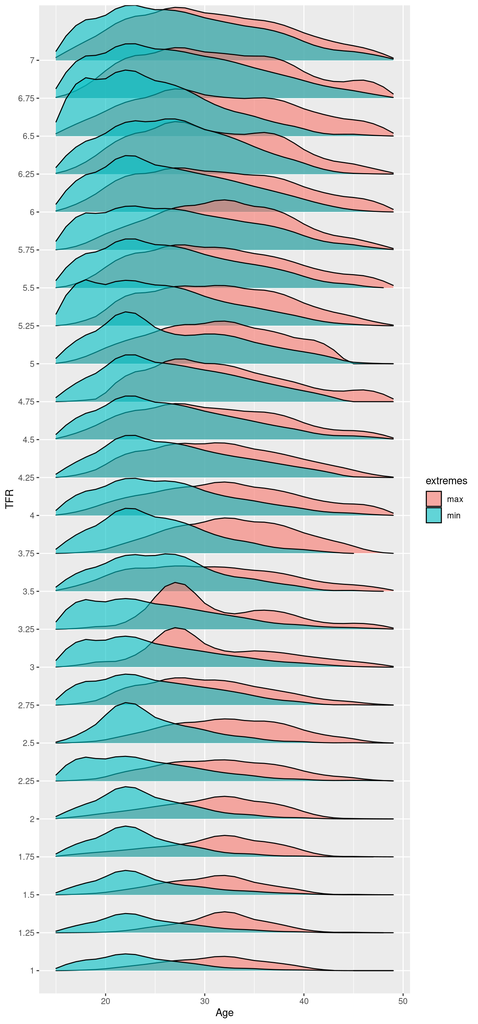

```r
#install.packages("ggridges")
library(ggridges)

ASFRex %>%
  filter(TFRint >= 1,
         TFRint < 7.1) %>%
  ggplot(mapping = aes(x = Age,
                y = factor(TFRint,
                                           levels = sort(unique(TFRint)),
                                           ordered = TRUE))) +
    geom_ridgeline(mapping = aes(x = Age,
                                               height = asfr,
                                               fill = extremes),
                   scale = 4,
                         alpha = .6) +
  labs(y = "TFR")
```

Looking at the results, we note a few odd cases, which could be problematic spline fits, or poor data quality. If we wanted to pursue this any further then these would require closer examination. I’m afraid some of these series might have poor quality, or else data gaps that cause the splines to behave bad, not sure. We could also try the Schmertmann or some other method. Let’s chalk this up as a win for now!

# References

Healy, Kieran. 2019. *Data Visualization: A Practical Introduction*. Princeton University Press.

Human Mortality Database. 2019. “University of California, Berkeley (USA) and Max Planck Institute for Demographic Research (Germany).”

Wickham, Hadley et al. 2014. “Tidy Data.” *Journal of Statistical Software* 59 (10): 1–23.

Wickham, Hadley. 2016. *Ggplot2: Elegant Graphics for Data Analysis*. Springer.

Wilkinson, Leland. 2012. “The Grammar of Graphics.” In *Handbook of Computational Statistics*, 375–414. Springer.